# Quiz 1

2023-10-17

## 시험시간: 2023년 10월 17일 13:10 ~ 14:10

## 제출: Html, Rmd 파일을 .zip으로 압축해 etl에 제출

#### 주의사항

- 전자기기(휴대폰 등)나 메신저(메일, 카톡 등)는 시험 중 절대로 사용할 수 없음. 사용이 적발 시 부정행위로 간주해 바로 퇴실조치.
- 시간 초과로 인해 제출하지 못하는 경우 책임은 수강생 본인에게 있음. 마감 시간 까지 문제를 푸는 것이 아닌, Knit과 etl 제출까지 완료해야 하므로 꼭 마지막 5~10분은 제출 준비 할 것.

```r
library(GenderInfer)
library(nycflights13)
library(tidyverse)
```

### Q1. `nycflights13` package의 `planes` 데이터를 사용하여 연도별로 제작사마다 비행기를 어느정도 생산해냈는지 알아보기 위한 도표나 그림을 출력하시오.

- 조건 1. 만든 비행기의 수가 200개 이하인 제조사에 대해는 분석에서 제외.
- 조건 2. 분석 결과를 해석할 것.

### A1.

```r
planes <- mutate_at(planes,vars(3,4,5,9),as_factor)
summary(planes)
```

```
##    tailnum               year                            type
##  Length:3322        Min.   :1956   Fixed wing multi engine :3292
##  Class :character   1st Qu.:1997   Fixed wing single engine:  25
##  Mode  :character   Median :2001   Rotorcraft              :   5
##                     Mean   :2000
##                     3rd Qu.:2005
##                     Max.   :2013
##                     NA's   :70
##             manufacturer          model         engines          seats
##  BOEING           :1630   737-7H4    : 361   Min.   :1.000   Min.   :  2.0
##  AIRBUS INDUSTRIE : 400   A320-232   : 256   1st Qu.:2.000   1st Qu.:140.0
##  BOMBARDIER INC   : 368   CL-600-2B19: 171   Median :2.000   Median :149.0
##  AIRBUS           : 336   CL-600-2D24: 123   Mean   :1.995   Mean   :154.3
##  EMBRAER          : 299   737-824    : 122   3rd Qu.:2.000   3rd Qu.:182.0
##  MCDONNELL DOUGLAS: 120   MD-88      : 117   Max.   :4.000   Max.   :450.0
##  (Other)          : 169   (Other)    :2172
##      speed                 engine
##  Min.   : 90.0   Turbo-fan    :2750
##  1st Qu.:107.5   Turbo-jet    : 535
##  Median :162.0   Reciprocating:  28
##  Mean   :236.8   4 Cycle      :   2
##  3rd Qu.:432.0   Turbo-shaft  :   5
##  Max.   :432.0   Turbo-prop   :   2
##  NA's   :3299
```

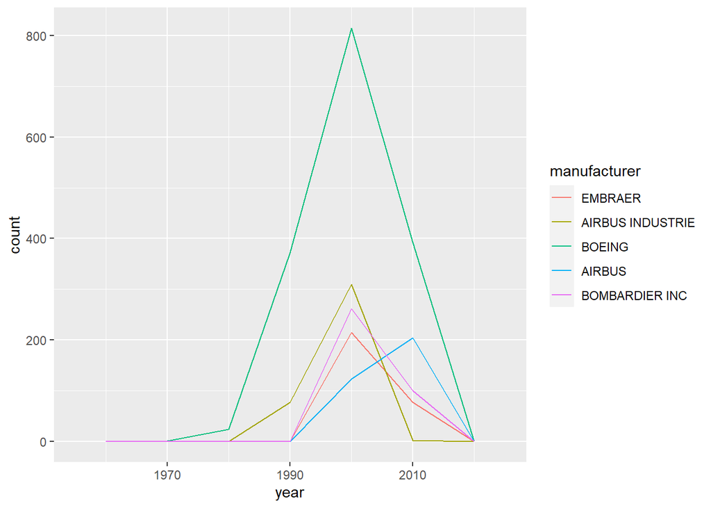

```r
planes %>%
  group_by(manufacturer) %>%
  mutate(n = n()) %>%
  filter(n >200 ) %>%
  ggplot(mapping = aes(x = year)) +
  geom_freqpoly(mapping = aes(colour = manufacturer),binwidth = 10)
```

2000년도 전후로 비행기 생산량이 급격하게 늘었음을 알 수 있다. 특히 AIRBUS 같은 경우는 가장 최근인 2010 년대에 많이 생산되었음을 알 수 있다.

### Q2. `GenderInfer` package의 `authors` 자료는 성별에 따른 출판 횟수에 관한 데이터이다. 변수 `publication_years`는 출판 연도를, `gender`는 성별 (M = male, F = felame, U = unknown)을 나타낸다. 각 성별이 출판을 가장 많이 한 년도와, 각각의 성별의 수를 나타내주는 아래 도표를 조건에 맞게 그대로 출력하시오. (아래 도표에서 most_published_year는 각 성별이 가장 많은 수의 출판을 한 년도를, count는 `authors_df` 자료에서 각 성별의 수를 의미.)

패키지를 부착하고 아래 코드를 이용해 `authors_df` 라는 dataframe을 생성하세요.

```r
authors_df <- assign_gender(data_df = authors, first_name_col = "first_name")
```

- 조건 1. `group_by`, `summarise` 함수를 이용해 `authors_df %>%` 에서 시작하여 pipe로 연결된 하나의 code chunk 를 통해 결과를 출력할 것.
- 조건 2. gender = U (Unknown) 인 경우는 missing으로 처리해주세요.
- 조건 3. column names 이 주어진 표와 일치해야 하며, 결과 표에 해당하는 숫자를 직접 대입해서 출력하면 0점처리 됩니다.

```
## # A tibble: 2 × 3
##   gender most_published_year count
##   <chr>                <int> <int>
## 1 F                     2016   396
## 2 M                     2019   428
```

### A2.

```r
authors_df %>%
  filter(gender != "U") %>%
  group_by(gender) %>%
  count(publication_years) %>%
  summarise(most_published_year = publication_years[rank(n)==length(n)],
            count = sum(n))
```

```
## # A tibble: 2 × 3
##   gender most_published_year count
##   <chr>                <int> <int>
## 1 F                     2016   396
## 2 M                     2019   428
```

### Q3. `NYC_Jobs.csv`는 뉴욕의 일자리 자료로, Job Category 변수는 직업의 종류, Salary는 연봉을 말한다. 직업군 간의 연봉 분포의 차이를 알아보기 위한 도표나 그림을 출력하시오.

- 조건 1. 비교하고자 하는 Job Category는 “Finance, Accounting, & Procurement”와 “Technology, Data & Innovation”와 “Health”이다.
- 조건 2. 연봉이 $10000 이하인 데이터는 outlier로 보고 삭제하여라.
- 조건 3. 연봉이 $200000 이상인 고연봉자는 plot 상에 표시하시오.
- 조건 4. 그린 plot에 대한 해석을 반드시 쓸 것.

### A3.

```r
nyc_job = read_csv("NYC_jobs.csv")
new_job = nyc_job %>% select(`Job Category`, `Salary`) %>%
  filter((`Job Category` == "Finance, Accounting, & Procurement" | `Job Category` == "Technology, Data & Innovation" | `Job Category` == "Health")) %>%
  filter(`Salary` > 10000)
head(new_job)
```

```
## # A tibble: 6 × 2
##   `Job Category`                     Salary
##   <chr>                               <dbl>
## 1 Health                              76872
## 2 Technology, Data & Innovation      102982
## 3 Technology, Data & Innovation       96238
## 4 Finance, Accounting, & Procurement  73243
## 5 Technology, Data & Innovation      109990
## 6 Technology, Data & Innovation      130000
```

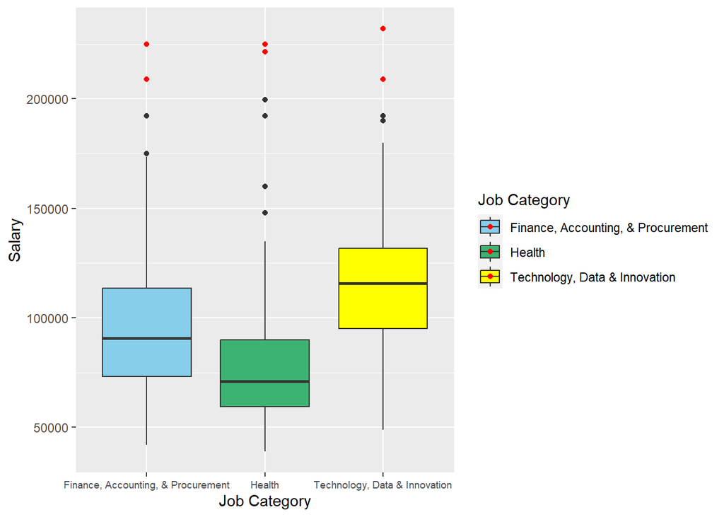

```r
ggplot(data = new_job, mapping = aes(x =  `Job Category`, y = `Salary`, fill = `Job Category`)) +
  geom_boxplot() + scale_fill_manual(values = c("#87CEEB",  "#3CB371","#FFFF00")) +
  geom_point(data = new_job %>% filter(`Salary` > 200000), color = "#FF0000") +
  theme(axis.text.x=element_text(size = 7))
```

Technology, Data & Innovation 직군에 근무하는 사람들의 연봉이 다른 직군에 비해 상대적으로 높은 것을 확인할 수 있으며 Health 직군에 근무하는 사람들의 연봉이 상대적으로 낮은 것을 확인할 수 있다. 또한 연봉이 $200000 이상인 고연봉자는 직군별로 2명씩 있는 것을 알 수 있다.